# Marketing Campaigns Project

#### 7. Test the following hypotheses:

NOTE: if the p-value is less than your significance level (commonly 0.05), you would reject the null hypothesis and conclude there is a statistically significant difference between the two groups.

**a. Older individuals may not possess the same level of technological proficiency and may, therefore, lean toward traditional in-store shopping preferences.**

```python
import pandas as pd
# Read the CSV and parse the date column
df = pd.read_csv("marketing_data.csv", parse_dates=True)
current_year = pd.to_datetime("today").year
print(current_year)
age=current_year-df['Year_Birth']
print(age)
# Find the maximum value across columns A, B, C, and D for each row
df['Max_Value'] = df[['NumWebPurchases', 'NumStorePurchases']].max(axis=1)

print(df['Max_Value'])
```

```
2025
0       55
1       64
2       67
3       58
4       36
        ..
2235    49
2236    48
2237    49
2238    47
2239    56
Name: Year_Birth, Length: 2240, dtype: int64
0        6
1        7
2        5
3        2
4        3
        ..
2235    11
2236     3
2237     6
2238    10
2239     8
Name: Max_Value, Length: 2240, dtype: int64
```

```python
import pandas as pd
import numpy as np
import scipy.stats as stats

# Read the CSV and parse the date column
df = pd.read_csv("marketing_data.csv", parse_dates=True)

# Clean Income Column (if needed)
df['Income'] = df[' Income '].replace({'\$': '', ',': ''}, regex=True).astype(float)

# Create Age Column
current_year = pd.to_datetime("today").year
df['Age'] = current_year - df['Year_Birth']

# Define Age Groups
def categorize_age(age):
    if age < 30:
        return '18-30'
    elif age < 50:
        return '31-50'
    else:
        return '51+'

df['Age_Group'] = df['Age'].apply(categorize_age)

# 1. ANOVA Test: Comparing Technological Proficiency (NumWebVisitsMonth) Across Age Groups
groups = [df[df['Age_Group'] == age]['NumWebVisitsMonth'] for age in df['Age_Group'].unique()]
anova_result = stats.f_oneway(*groups)
print("ANOVA Test for Web Visits across Age Groups:", anova_result)

# 2. Chi-Square Test: Shopping Preference (Online vs. In-Store) vs. Age Group
df['Shopping_Preference'] = np.where(df['NumWebPurchases'] > df['NumStorePurchases'], 'Online', 'In-Store')
contingency_table = pd.crosstab(df['Age_Group'], df['Shopping_Preference'])
chi2, p, dof, expected = stats.chi2_contingency(contingency_table)
print("\nChi-Square Test for Shopping Preference vs. Age Group:")
print(f"Chi2: {chi2}, P-value: {p}")

# Conclusion
alpha = 0.05
if anova_result.pvalue < alpha:
    print("\nTechnological proficiency (web visits) significantly differs across age groups.")
else:
    print("\nNo significant difference in technological proficiency across age groups.")

if p < alpha:
    print("Shopping preference is significantly related to age group.")
else:
    print("No significant relationship between shopping preference and age group.")
```

```
ANOVA Test for Web Visits across Age Groups: F_onewayResult(statistic=4.106997445268869, pvalue=0.01658136752767309)

Chi-Square Test for Shopping Preference vs. Age Group:
Chi2: 8.817950057802609, P-value: 0.012167643423491636

Technological proficiency (web visits) significantly differs across age groups.
Shopping preference is significantly related to age group.
```

**b. Customers with children likely experience time constraints, making online shopping a more convenient option.**

```python
import pandas as pd
import numpy as np
import scipy.stats as stats

# Read the CSV and parse the date column
df = pd.read_csv("marketing_data.csv", parse_dates=True)

# Clean Income Column (if needed)
df['Income'] = df[' Income '].replace({'\$': '', ',': ''}, regex=True).astype(float)

# Create Age Column
df['Age'] = 2025 - df['Year_Birth']

# Define Age Groups
def categorize_age(age):
    if age < 30:
        return '18-30'
    elif age < 50:
        return '31-50'
    else:
        return '51+'

df['Age_Group'] = df['Age'].apply(categorize_age)

# Create 'Has_Children' column
df['Has_Children'] = np.where((df['Kidhome'] + df['Teenhome']) > 0, 'Yes', 'No')

# Categorize Shopping Preference
df['Shopping_Preference'] = np.where(df['NumWebPurchases'] > df['NumStorePurchases'], 'Online', 'In-Store')

# 1. ANOVA Test: Comparing Technological Proficiency (NumWebVisitsMonth) Across Age Groups
groups = [df[df['Age_Group'] == age]['NumWebVisitsMonth'] for age in df['Age_Group'].unique()]
anova_result = stats.f_oneway(*groups)
print("ANOVA Test for Web Visits across Age Groups:", anova_result)

# 2. Chi-Square Test: Shopping Preference (Online vs. In-Store) vs. Age Group
contingency_table = pd.crosstab(df['Age_Group'], df['Shopping_Preference'])
chi2, p, dof, expected = stats.chi2_contingency(contingency_table)
print("\nChi-Square Test for Shopping Preference vs. Age Group:")
print(f"Chi2: {chi2}, P-value: {p}")

# 3. Chi-Square Test: Shopping Preference vs. Having Children
contingency_children = pd.crosstab(df['Has_Children'], df['Shopping_Preference'])
chi2_child, p_child, dof_child, expected_child = stats.chi2_contingency(contingency_children)
print("\nChi-Square Test for Shopping Preference vs. Having Children:")
print(f"Chi2: {chi2_child}, P-value: {p_child}")

# 4. T-Test: Compare Online Purchases Between Parents and Non-Parents
ttest_result = stats.ttest_ind(df[df['Has_Children'] == 'Yes']['NumWebPurchases'],
                               df[df['Has_Children'] == 'No']['NumWebPurchases'],
                               equal_var=False)
print("\nT-Test for Online Purchases Between Customers with and without Children:", ttest_result)

# Conclusion
alpha = 0.05
if anova_result.pvalue < alpha:
    print("\nTechnological proficiency (web visits) significantly differs across age groups.")
else:
    print("\nNo significant difference in technological proficiency across age groups.")

if p < alpha:
    print("Shopping preference is significantly related to age group.")
else:
    print("No significant relationship between shopping preference and age group.")

if p_child < alpha:
    print("\nShopping preference is significantly related to having children.")
else:
    print("\nNo significant relationship between shopping preference and having children.")

if ttest_result.pvalue < alpha:
    print("Customers with children make significantly more online purchases.")
else:
    print("No significant difference in online purchases between customers with and without children.")
```

[output not shown]

**c. Sales at physical stores may face the risk of cannibalization by alternative distribution channels.** NOTE: Corporate cannibalism is when a product sees a decrease in sales volume or market share due to the release of some new product that has been introduced by the same company.

```python
import pandas as pd
import numpy as np
import scipy.stats as stats
import statsmodels.api as sm

# Read the CSV and parse the date column
df = pd.read_csv("marketing_data.csv", parse_dates=True)

# Check for missing values in relevant columns
df = df[['NumWebPurchases', 'NumStorePurchases']].dropna()

# 1. Correlation Analysis
correlation = df[['NumWebPurchases', 'NumStorePurchases']].corr().iloc[0, 1]

# 2. Linear Regression (Predict Store Purchases based on Web Purchases)
X = df['NumWebPurchases']
Y = df['NumStorePurchases']
X = sm.add_constant(X)  # Add intercept
model = sm.OLS(Y, X).fit()

# 3. T-Test: Compare store purchases between high and low online shoppers
median_web_purchases = df['NumWebPurchases'].median()
high_online_shoppers = df[df['NumWebPurchases'] > median_web_purchases]['NumStorePurchases']
low_online_shoppers = df[df['NumWebPurchases'] <= median_web_purchases]['NumStorePurchases']
ttest_result = stats.ttest_ind(high_online_shoppers, low_online_shoppers, equal_var=False)

# Results
correlation, model.params[1], model.pvalues[1], ttest_result.pvalue
```

```
(0.502713413299731,
 0.5881498344990793,
 8.962802398073471e-144,
 2.0185377858696517e-123)
```

**d. Does the United States significantly outperform the rest of the world in total purchase volumes?**

```python
import pandas as pd
import numpy as np
import scipy.stats as stats
import statsmodels.api as sm

# Read the CSV and parse the date column
df = pd.read_csv("marketing_data.csv", parse_dates=True)
df['Total_Purchases']=df.loc[:,'NumDealsPurchases':'NumStorePurchases'].sum(axis=1)
print(df['Total_Purchases'])
# Split data into two groups: US vs. Rest of the World
us_purchases = df[df["Country"] == "US"]["Total_Purchases"]
non_us_purchases = df[df["Country"] != "US"]["Total_Purchases"]

# Perform independent t-test
t_stat, p_value = ttest_ind(us_purchases, non_us_purchases, equal_var=False)  # Welch’s t-test

# Display results
t_stat, p_value
```

[output not shown]

```
0       15
1       18
2       11
3        4
4        8
        ..
2235    20
2236     5
2237    14
2238    20
2239    18
Name: Total_Purchases, Length: 2240, dtype: int64
```

```python
from sklearn.preprocessing import LabelEncoder, MinMaxScaler

# Convert categorical Country values to numbers
le = LabelEncoder()
df['Country_Encoded'] = le.fit_transform(df['Country'])

# Apply MinMaxScaler
scaler = MinMaxScaler()
df['Country_Scaled'] = scaler.fit_transform(df[['Country_Encoded']])

print(df[['Country', 'Country_Encoded', 'Country_Scaled']].head())
```

```
  Country  Country_Encoded  Country_Scaled
0      SP                6        0.857143
1      CA                1        0.142857
2      US                7        1.000000
3     AUS                0        0.000000
4      SP                6        0.857143
```

```python
correlation = df[['Country_Encoded', 'NumWebPurchases']].corr().iloc[0, 1]
correlation
```

```
-0.012984863718658583
```

#### Use appropriate visualization to help analyze the following:

**a. Identify the top-performing products and those with the lowest revenue.**

```python
import pandas as pd
import matplotlib.pyplot as plt

# Read the CSV and parse the date column
df = pd.read_csv("marketing_data.csv", parse_dates=True)

# List of columns representing product revenues
revenue_cols = ["MntWines", "MntFruits", "MntMeatProducts", "MntFishProducts", "MntSweetProducts", "MntGoldProds"]

# Calculate total revenue for each product category by summing the column values across all customers
total_revenue = df[revenue_cols].sum()

# Sort the total revenue in descending order (top-performing first)
sorted_revenue = total_revenue.sort_values(ascending=False)
print("Total Revenue by Product Category:")
print(sorted_revenue)

# Identify the top-performing product (highest revenue)
top_product = sorted_revenue.idxmax()
print("\nTop-performing product:", top_product)

# Identify the product with the lowest revenue
lowest_product = sorted_revenue.idxmin()
print("Product with the lowest revenue:", lowest_product)
```

[output not shown]

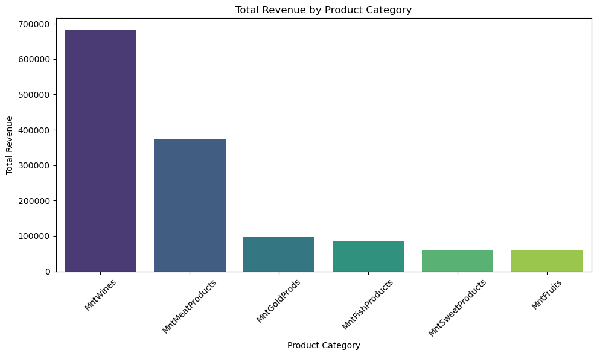

```python
import matplotlib.pyplot as plt
import seaborn as sns

# List of revenue columns
revenue_cols = ["MntWines", "MntFruits", "MntMeatProducts",
                "MntFishProducts", "MntSweetProducts", "MntGoldProds"]

# Calculate total revenue for each product category
total_revenue = df[revenue_cols].sum()

# Sort the total revenue in descending order
sorted_revenue = total_revenue.sort_values(ascending=False)

# Create a bar chart using seaborn
plt.figure(figsize=(10, 6))
sns.barplot(x=sorted_revenue.index, y=sorted_revenue.values, palette="viridis")
plt.xlabel("Product Category")
plt.ylabel("Total Revenue")
plt.title("Total Revenue by Product Category")
plt.xticks(rotation=45)
plt.tight_layout()
plt.show()
```

**b. Examine if there is a correlation between customers' age and the acceptance rate of the last campaign.**

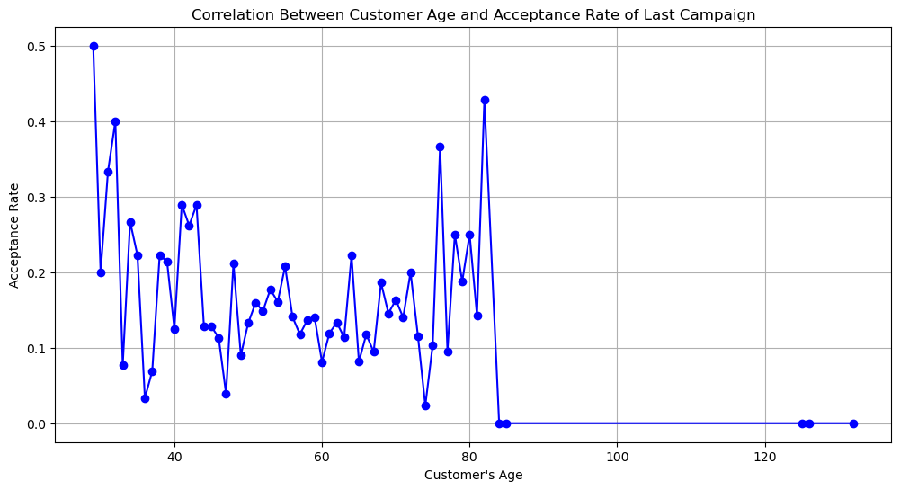

```python
import pandas as pd
import matplotlib.pyplot as plt
from datetime import datetime

# Read the dataset
df = pd.read_csv("marketing_data.csv")

# Compute age: current year minus Year_Birth
current_year = datetime.now().year
df["Age"] = current_year - df["Year_Birth"]

# Calculate the acceptance rate per age by grouping and taking the mean of 'Response'
# Assuming 'Response' is 1 for accepted, 0 for not accepted
acceptance_rate_by_age = df.groupby("Age")["Response"].mean()

# Visualize the acceptance rate vs. age
plt.figure(figsize=(12, 6))
plt.plot(acceptance_rate_by_age.index, acceptance_rate_by_age.values, marker='o', linestyle='-', color='blue')
plt.xlabel("Customer's Age")
plt.ylabel("Acceptance Rate")
plt.title("Correlation Between Customer Age and Acceptance Rate of Last Campaign")
plt.grid(True)
plt.show()
```

**c. Determine the country with the highest number of customers who accepted the last campaign.**

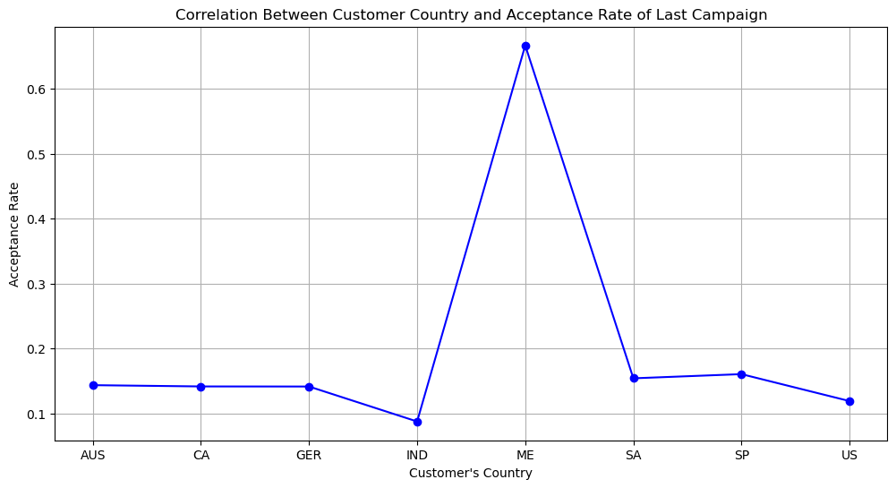

```python
import pandas as pd
import matplotlib.pyplot as plt
from datetime import datetime

# Read the dataset
df = pd.read_csv("marketing_data.csv")

# Calculate the acceptance rate by country by grouping and taking the mean of 'Response'
# Assuming 'Response' is 1 for accepted, 0 for not accepted
acceptance_rate_by_country = df.groupby("Country")["Response"].mean()

# Visualize the acceptance rate vs. Country
plt.figure(figsize=(12, 6))
plt.plot(acceptance_rate_by_country.index, acceptance_rate_by_country.values, marker='o', linestyle='-', color='blue')
plt.xlabel("Customer's Country")
plt.ylabel("Acceptance Rate")
plt.title("Correlation Between Customer Country and Acceptance Rate of Last Campaign")
plt.grid(True)
plt.show()
```

**d. Investigate if there is a discernible pattern in the number of children at home and the total expenditure.**